# meth01_process_data

SHARP Epigenetics Bootcamp 2025

```r
.libPaths( c('.Rpackages',.libPaths() ) )
```

Load required libraries (ignore warning messages)

```r
library(stringi)
library(magrittr)
library(data.table)
library(svd)
library(ewastools)

# setwd('/cloud/project')
```

## Importing the data

Metadata stored in `data/pheno.csv` is imported using `fread` from the data.table package and stored in the object `pheno`

```r
pheno = fread("data/pheno.csv")
```

Take a look at the metadata

```r
pheno
```

```
##            gsm   age    Sex smoker   Sentrix_ID    row    col
##         <char> <num> <char>  <int>        <i64> <char> <char>
##  1: GSM7866977 31.79      m      1 207700470036    R08    C01
##  2: GSM7867039 25.81      m      1 207700460068    R02    C01
##  3: GSM7867098 36.34      f      1 207700460020    R03    C01
##  4: GSM7867112 72.16      m      1 207805820161    R04    C01
##  5: GSM7867122 61.02      f      1 207805820128    R04    C01
##  6: GSM7867159 49.88      m      1 207686150104    R04    C01
##  7: GSM7867181 65.34      m      1 207700460111    R01    C01
##  8: GSM7867204 60.30      f      1 207805820146    R01    C01
##  9: GSM7867222 57.82      m      1 207700460069    R04    C01
## 10: GSM7867227 45.44      m      1 207700470024    R06    C01
## 11: GSM7867316 52.13      m      1 207686140125    R02    C01
## 12: GSM7867370 58.91      m      1 207700460035    R02    C01
## 13: GSM7867379 79.46      f      1 207700460028    R06    C01
```

[output cut: 21 more lines]

Column `gsm` is the sample ID (GEO acession) as well as the first part of the file name. For each sample there are two files, `$$$_Red.idat(.gz)` and `$$$_Grn.idat(.gz)`, containing fluorescence intensities in the red and green color channel, respectively. Import the data using `read_idats`. Provide only the `$$$` part of the file name. Store in object `meth`.

```r
meth = read_idats("data/" %s+% pheno$gsm)
```

[output not shown]

`meth` is a list. Take a look at the some of the list items

```r
names(meth)
```

```
##  [1] "platform" "manifest" "U"        "T"        "V"        "M"
##  [7] "S"        "N"        "controls" "ctrlG"    "ctrlR"    "ctrlN"
## [13] "oobG"     "oobR"     "meta"
```

Which platform was used.

```r
meth$platform
```

```
## [1] "EPICv2"
```

`manifest` is a data.table with information about all the probes on the chip

```r
meth$manifest[126659:126664]
```

```
##            ilmn_id   probe_id addressU addressM next_base channel probe_type
##             <char>     <char>    <int>    <int>    <fctr>  <fctr>     <fctr>
## 1: cg02478419_BC11 cg02478419 85600876 39680362         C     Grn         cg
## 2: cg02477503_BC11 cg02477503 10727471 36740365         C     Grn         cg
## 3: cg02468509_BC11 cg02468509 24726279 40732920         A     Red         cg
## 4: cg02414726_BC11 cg02414726 40622395 19646573         C     Grn         cg
## 5: cg25335775_BC21 cg25335775 38697209       NA      <NA>    Both         cg
## 6: cg25341653_BC21 cg25341653 46709362       NA      <NA>    Both         cg
##    probe_design    chr   mapinfo probe_rep  chr37 mapinfo37  index  OOBi     Ui
##          <fctr> <fctr>     <int>     <int> <fctr>     <int>  <int> <int>  <int>
## 1:            I   chr2  16070558         1   chr2  16210680 126659 44723 919762
## 2:            I   chr2  15993337         1   chr2  16133459 126660 44724 128138
## 3:            I   chr2  15142498         1   chr2  15282622 126661 81937 257833
## 4:            I   chr2   9975630         1   chr2  10115758 126662 44725 384682
## 5:           II   chr1 175023178         1   chr1 174992314 126663    NA 371620
## 6:           II  chr16  67199374         1  chr16  67233277 126664    NA 468790
##        Mi
##     <int>
## 1: 379001
## 2: 357672
## 3: 392286
## 4: 207151
## 5: 371620
## 6: 468790
```

For example, `ilmn_id` is a unique identifier for each probe for EPICv2 datasets, `probe_id` is the legacy identifier for each probe.  
The combination of `chr` and `mapinfo` gives the genomic coordinates of the targeted loci. The column `probe_type` refers to the type of loci that are targeted by these probes. Here, all the probes are CpG sites, i.e., “cg”.

**QUESTION: What other type of loci besides CpG sites are there?**  
ANSWER: There are also CHH sites (ch), SNPs (rs), and new variants (nv).

The column `channel` tells us the color channel and Infinium probe design type.  
“Grn” and “Red” denote Infinium Type I, “Both” denotes Type II.

`addressU` and `addressM` are the unique identifier of the beads (a probe consists of one or two beads).

**QUESTION: Why is the column `addressM` missing for entries with `channel=="Both"`?**  
ANSWER: As type II probes use the same bead for methylated and unmethylated signal, the information would be redundant

Some columns (`index`,`OOBi`,`Ui`,`Mi`) are used for the internal workings of the `ewastools` package and not of interest for the user

Fluorescence intensities observed at the bead locations are stored in list items `M` (methylated) and `U` (unmethylated) (`U`).

```r
dim(meth$M)
```

```
## [1] 937055     33
```

The matrix has 937,055 rows, one for each probe, and 33 columns, one for each sample

Let’s look at these fluorescence intensities for three probes in three samples.

```r
meth$U[290:292,1:3]
```

```
##       [,1]  [,2]  [,3]
## [1,] 14613 13089 14149
## [2,]   667   384   824
## [3,] 16315 13869 14873
```

```r
meth$M[290:292,1:3]
```

```
##       [,1]  [,2]  [,3]
## [1,]   696   414   581
## [2,] 17471 14190 19902
## [3,]   698   358   471
```

**QUESTION: Comparing corresponding entries across `U` and `M` above, what can you infer about these loci?**  
ANSWER: For the middle probe, the methylated intensities are much higher than the unmethylated intensities. This probe is methylated across the three samples

Because of the random assembly of the chips, the copy number can vary for each bead, and the values in `U` and `M` are actually averages. Copy numbers are stored in `V` (corresponding to `U`) and `N` (corresponding to `M`). For some beads the copy number can be zero.

```r
dim(meth$N)
```

```
## [1] 937055     33
```

```r
meth$N[290:292,1:3]
```

```
##      [,1] [,2] [,3]
## [1,]   12   12   15
## [2,]   13   15   16
## [3,]   10   11   11
```

**QUESTION: How many probes are missing in the first sample?**  
ANSWER: 16 probes have no beads present for either the unmethylated or methylated type

**QUESTION: Why are for type II probes the entries in `N` and `V` are always the same.**  
ANSWER: Because the same beads are used to measure methylated and unmethylated signal

The `meth` list includes more elements, among them matrices and a manifest for control probes. The control probes don’t target CpG sites, but are used to monitor the various experimental steps or are used for pre-processing. We will make use of them for quality control.

## Quality control

Create a flag for samples that we want to exclude from the final dataset

```r
pheno[,exclude:=FALSE]
```

### Control metrics

The first quality check evaluates 17 control metrics which are described in the BeadArray Controls Reporter Software Guide from Illumina.  
`control_metrics()` calculates the control metrics from the control probes  
`sample_failure()` evaluates control metrics against pre-defined thresholds

```r
meth |> control_metrics() |> sample_failure() -> pheno$failed
```

Here we are making use of the pipe operator (|>) from the `magrittr` package. The line above is equivalent to (i.e., could be alternatively written as)

```r
pheno$failed = sample_failure(control_metrics(meth))
```

**QUESTION: How many samples failed this check?**  
ANSWER: None

### Detection p-values

`detectionP()` calculates detection p-values and stores them in a new list item `detP`. Detection p-values should be based on raw data, i.e., before pre-processing such as dye-bias correction. We will use `mask()` later to drop those observations with p-values above a specified cut-off

```r
meth = ewastools::detectionP(meth)
```

Comparison of detection p-values for probes targeting the Y chromosome across males and females  
Get the indices of the probes

```r
chrY = meth$manifest[chr == "chrY", index]
length(chrY)
```

```
## [1] 667
```

There are 667 such probes on EPICv2

Retrieve the corresponding p-values

```r
detP = meth$detP[chrY, ]
```

Count those below 0.01 as detected

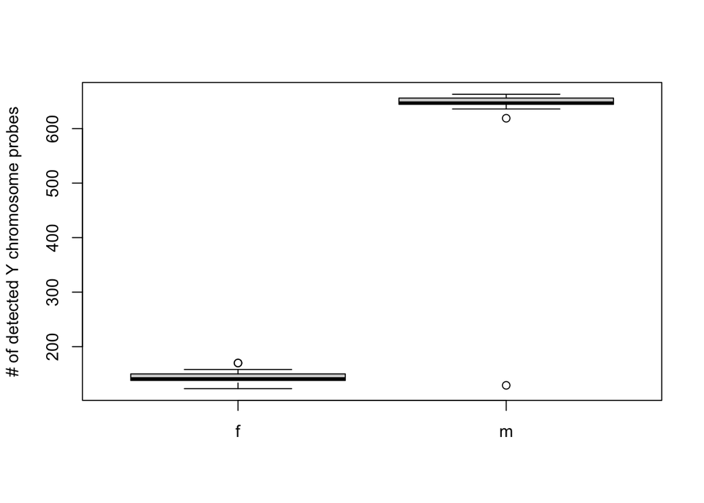

```r
detP = colSums(detP < 0.01, na.rm = TRUE)

boxplot(split(detP,pheno$Sex), ylab = "# of detected Y chromosome probes")
```

```r
split(detP, pheno$Sex) |> sapply(median)
```

```
##   f   m
## 141 647
```

Almost all of the 667 Y-chromosomal probes are called detected in the males whereas among females 141 probes are detected on average.

**QUESTION: Excluding the Y chromosome and missing probes, what is the percentage of undetected (0.01 cut-off) probes in the first sample. Use `table()`.**  
ANSWER: 5134 / (5134 + 931238), roughly 0.5%

### Dye-bias correction

Infinium BeadChips use two fluorescent dyes that are linked to the nucleotides added during the the single-base extension step. A and T nucleotides are linked with a red dye (the red color channel), G and C nucleotides are linked with a green dye (green color channel). Uncorrected data usually feature higher intensities in the red color channel, the so-called dye bias.  
For probes of Infinium type II design, which use separate color channels to measure the methylated and unmethylated signal, this results in a shifted distribution of beta values. Probes of Infinium design type I are less affected, as they measure both signals in the same color channel.

`correct_dye_bias()` adjusts the green color channel using the red color channel as reference. The adjustment is performed on the log scale.

```r
meth |> dont_normalize()                       -> with_bias
meth |> correct_dye_bias() |> dont_normalize() -> corrected
```

Looking at the same loci as before we can check whether dye-bias correction changed the beta values  
Each probe is of a different type/color channel

```r
meth$manifest$channel[290:292]
```

```
## [1] Grn Red Grn
## Levels: Red Both Grn
```

```r
with_bias[290:292, 1:3] |> round(4)
```

```
##                 GSM7866977 GSM7867039 GSM7867098
## cg07139762_TC11     0.0455     0.0307     0.0394
## cg07197585_BC11     0.9632     0.9737     0.9602
## cg07248043_TC11     0.0410     0.0252     0.0307
```

```r
corrected[290:292, 1:3] |> round(4)
```

```
##                 GSM7866977 GSM7867039 GSM7867098
## cg07139762_TC11     0.0574     0.0350     0.0378
## cg07197585_BC11     0.9632     0.9737     0.9602
## cg07248043_TC11     0.0523     0.0290     0.0293
```

**QUESTION: Why are the beta values for cg07197585_BC11 unchanged?**  
ANSWER: Because the red color channel is used as reference.

Plotting beta values for heterozygous SNPs, we can observe the dye bias as a deviation from 0.5. For the corrected data, the middle peak aligns with 0.5

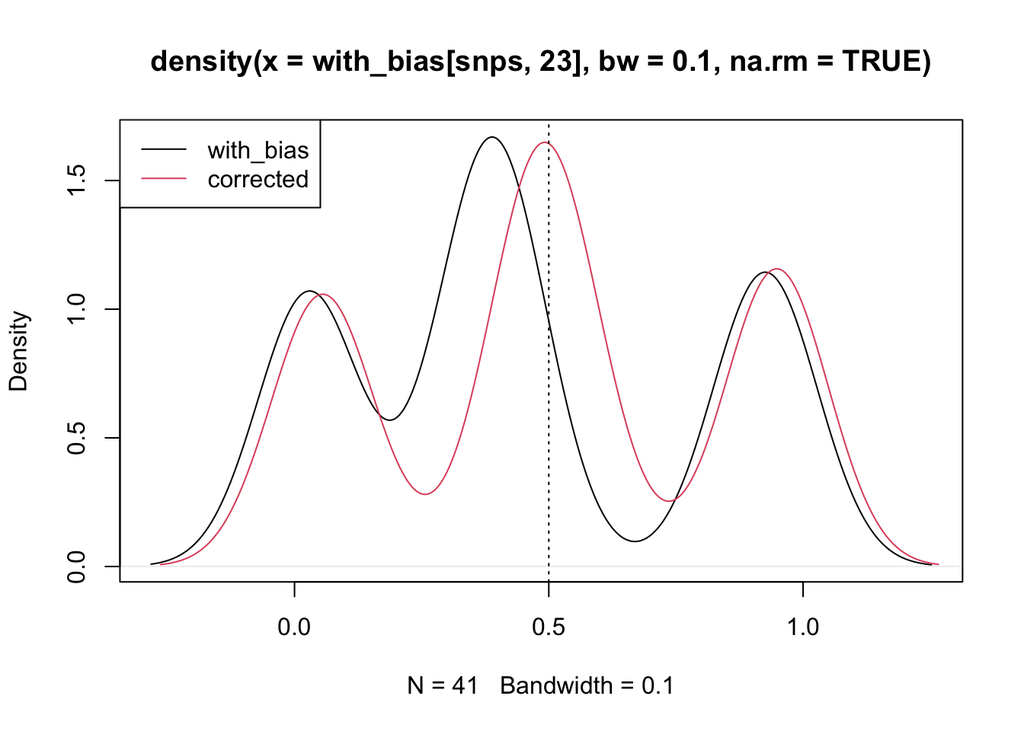

```r
snps = meth$manifest[probe_type == "rs" & channel == "Both"]$index

plot (density(with_bias[snps, 23], na.rm = TRUE, bw = 0.1), col = 1)
lines(density(corrected[snps, 23], na.rm = TRUE, bw = 0.1), col = 2)
abline(v = 0.5, lty = 3)
legend("topleft", col = 1:2, legend = c("with_bias", "corrected"), lwd = 1)
```

```r
meth |> correct_dye_bias() -> meth
rm(corrected,with_bias)
```

### Sex check

`check_sex()` computes the normalized average total fluorescence intensity of probes targeting the X and Y chromosomes, and `predict_sex()` infers the sex of the sample donors based on this information. This check should be applied after dye-bias correction but before undetected probes are masked as the latter step drops the Y chromosome probes among females

```r
pheno[, c("X", "Y") := check_sex(meth)]
pheno[, predicted_sex := predict_sex(X, Y, which(Sex=="m"), which(Sex=="f"))]
```

Are there instances where the sex inferred from the methylation data does not match the information in the recorded meta data?

```r
pheno[Sex != predicted_sex, .(gsm, Sex, predicted_sex)]
```

```
##           gsm    Sex predicted_sex
##        <char> <char>        <fctr>
## 1: GSM7867094      m             f
```

This is indeed the case for the sample with the ID GSM7867094. This most likely means that this sample was mislabeled.  
We flag this sample for exclusion

```r
pheno[Sex != predicted_sex, exclude := TRUE]
```

Let’s also plot these data

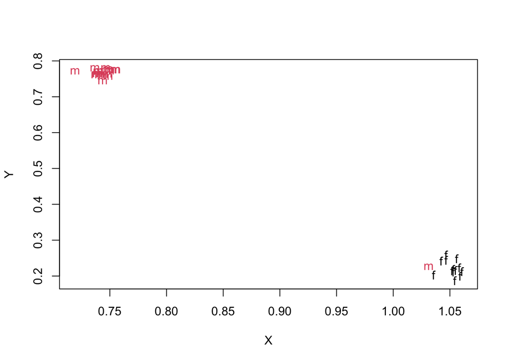

```r
plot(Y ~ X, data = pheno, type = "n")
text(Y ~ X, labels = Sex, col = ifelse(Sex == "m", 2, 1), data = pheno)
```

The mislabeled sample can be easily spotted as it falls into the wrong cluster.

Before the next QC steps, we should mask undetected probes. Here we use a cut-off of 0.01

```r
meth = mask(meth, 0.01)
```

Now we can compute a “clean” matrix of beta values. Undetected probes are set to NA

```r
beta = dont_normalize(meth)
```

### SNP outliers

`snp_outliers()` returns the average log odds of a SNP probe belonging to the outlier component of the mixture model. Here a cut-off of -4 is used as threshold for exclusion.

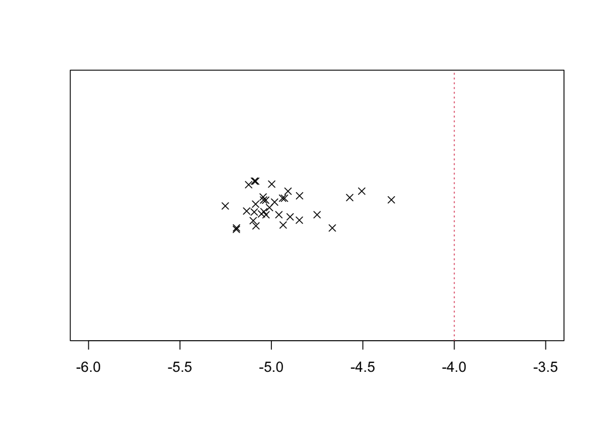

```r
snps = meth$manifest[probe_type == "rs"]$index
genotypes = call_genotypes(beta[snps, ], learn = FALSE)
pheno$outlier = snp_outliers(genotypes)

stripchart(pheno$outlier, method="jitter", pch = 4, xlim = c(-6, -3.5))
abline(v = -4, lty = "dotted", col = 2)
```

None of the samples fail this QC check

### Check for duplicates

The function `enumerate_sample_donors()` can be used to find samples with the same genetic fingerprint

```r
pheno$donor_id = enumerate_sample_donors(genotypes)
```

Find donor IDs represented more than once

```r
pheno[,n := .N, by = donor_id]
pheno[n>1, .(gsm, donor_id)]
```

```
## Empty data.table (0 rows and 2 cols): gsm,donor_id
```

None of the samples fail this QC check

### Principal component analysis

PCA is a popular feature reduction method: it projects high-dimensional data onto a lower-dimensional representation while trying to retain as much variability as possible.

```r
set.seed(292846330)
```

We will apply PCA to the matrix of beta values but without SNPs and the probes targeting the allosomes.

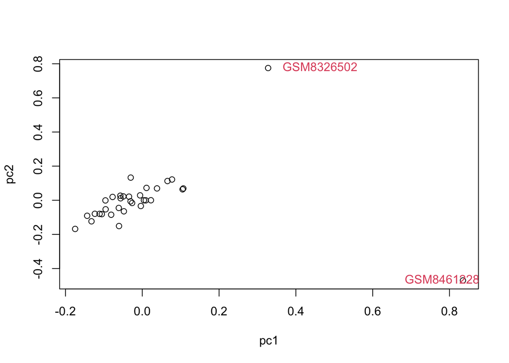

```r
chrXY =  meth$manifest[ chr %in% c("chrX","chrY") | probe_type == "rs"]$index
pcs = beta[-chrXY,]
pcs = pcs - rowMeans(pcs)
pcs = na.omit(pcs)
pcs = t(pcs)
pcs = trlan.svd(pcs,neig=2) # Just the first two principal components
pcs = pcs$u

pheno$pc1 = pcs[,1]
pheno$pc2 = pcs[,2]

plot(pc2 ~ pc1, col = ifelse(Sex == "M", 2, 1), data = pheno)
text(pc2 ~ pc1, labels = pheno[32]$gsm, data = pheno[32], pos = 4, offset =  1, col = 2)
text(pc2 ~ pc1, labels = pheno[33]$gsm, data = pheno[33], pos = 4, offset = -4, col = 2)
```

GSM8461228 is actually a brain tissue sample from another GEO dataset. It dominates the first principal component and should be excluded as it could drastically change the results of the downstream analysis.

```r
pheno[gsm == "GSM8461228", exclude := TRUE]
```

GSM8326502 is an isolated T cell sample that should also be removed based on the PC plot, but we will temporarily leave it in to demonstrate cell proportion estimates

PCA may be applied iteratively. After excluding samples that manifest as outliers, repeating PCA can give very different principal components.

### Leukocyte composition

This quality check will only apply in case of blood samples (blood is, however, one of the most commonly studied tissues). The function `estimateLC()` implements the Houseman method (doi.org/10.1186/1471-2105-13-86) to predict the leukocyte composition. Further choices include a more granular 15 cell type model derived from the Health and Retirement study (see `?estimateLC` for a list of options). The function operates on the matrix of beta values.

Option “HRS” provides proportions of 15 cell types

```r
colnames(estimateLC(beta, ref = "HRS"))
```

```
##  [1] "NE"    "EO"    "BA"    "MO"    "EM_CT" "CM_CT" "E_CT"  "N_CT"  "EM_HT"
## [10] "CM_HT" "E_HT"  "N_HT"  "B"     "DC"    "NK"
```

We are using the Reinius reference dataset

```r
LC = estimateLC(beta, ref = "Reinius", constrained = TRUE)
```

`LC` is a data.table. We can easily add to `pheno`

```r
pheno = cbind(pheno, LC)
```

Plot the proportions of CD4 versus (the column named `CD4`)

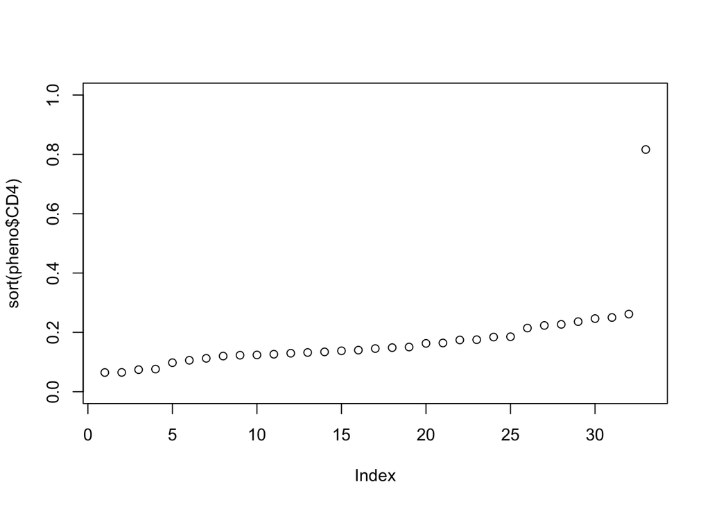

```r
plot(sort(pheno$CD4), ylim = c(0,1))
```

We observe one outlier, a sample with a CD4 proportion >80%

```r
pheno[which.max(CD4), .(gsm,exclude)]
```

```
##           gsm exclude
##        <char>  <lgcl>
## 1: GSM8326502   FALSE
```

GSM8326502 is an isolated T cell sample. Flag for exclusion.

```r
pheno[gsm == "GSM8326502", exclude := TRUE]
```

Let’s confirm that the leukocyte composition is confounded with smoking status LC stratified by smoking status

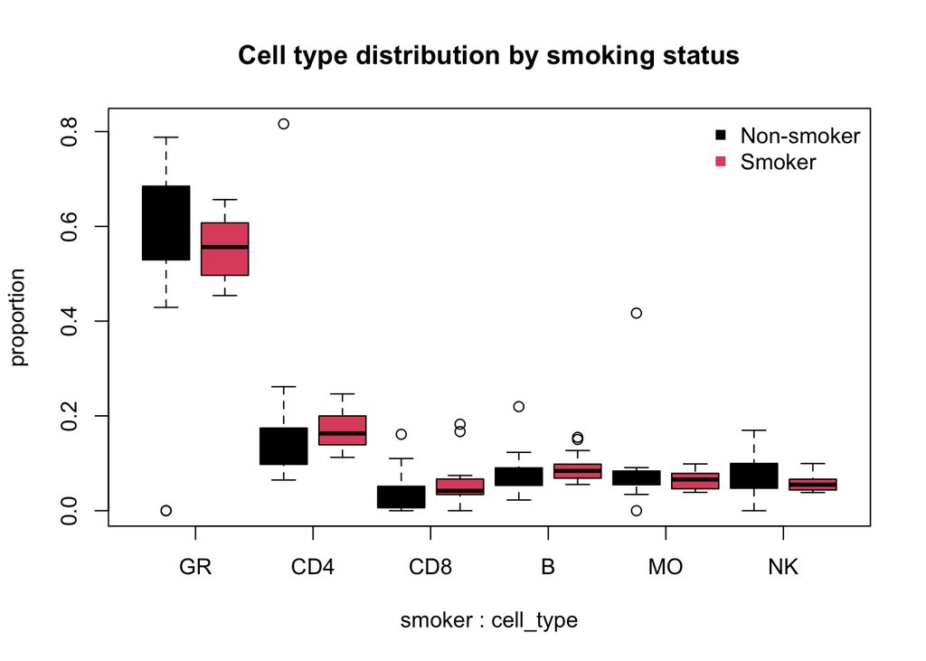

```r
LC$smoker = pheno$smoker
LC = melt(LC, value.name = "proportion", variable.name = "cell_type", id.vars = "smoker")

boxplot(proportion ~ smoker + cell_type, LC, col = 1:2,
    main = "Cell type distribution by smoking status", xaxt = "n")
axis(1, at = seq(from = 1.5, to = 11.5, by = 2), adj = 1, labels = unique(LC$cell_type))
legend("topright", c("Non-smoker", "Smoker"), pch = 15, bty = 'n', col = 1:2)
```

### Clean up

Keep only samples that passed all quality checks

```r
keep = which(!pheno$exclude)
pheno = pheno[keep]
beta  = beta[,keep]
```

Keep only the columns relevant for downstream analysis

```r
pheno = pheno[,.(gsm, smoker, Sentrix_ID, row,col, Sex,age, CD4,CD8,NK,MO,GR,B)]
```

Average across replicate probes

```r
manifest = copy(meth$manifest)
head(manifest[, 1:2])
```

```
##            ilmn_id   probe_id
##             <char>     <char>
## 1: cg25324105_BC11 cg25324105
## 2: cg25383568_TC11 cg25383568
## 3: cg25455143_BC11 cg25455143
## 4: cg25459778_BC11 cg25459778
## 5: cg25487775_BC11 cg25487775
## 6: cg25595446_BC11 cg25595446
```

```r
beta <- sesame::betasCollapseToPfx(beta)
```

Save a subset of the beta matrix, excluding non-autosomal probes and non-cg probes

```r
toExclude <- subset(manifest, manifest$probe_type != "cg" |
                    manifest$chr %in% c("chrX", "chrY", "chr0", "chrM"))
toExclude <- toExclude$probe_id
beta <- beta[!row.names(beta) %in% toExclude, ]

manifest <- subset(manifest, manifest$probe_type == "cg" &
                    !manifest$chr %in% c("chrX", "chrY", "chr0", "chrM"))
```

Also save a copy of the manifest

```r
manifest <- subset(manifest, manifest$probe_id %in% row.names(beta))
manifest <- manifest[match(unique(manifest$probe_id), manifest$probe_id),]
```

```r
save(pheno,manifest,beta,file="data/processed.rda")
```

```r
rm(list = ls()); gc()
```

```
##            used  (Mb) gc trigger   (Mb) limit (Mb)  max used   (Mb)
## Ncells  9655286 515.7   22601492 1207.1         NA  22601492 1207.1
## Vcells 35674857 272.2  424188518 3236.4      65536 530235647 4045.4
```